# l12_en_full

## Another example: Fridays for future

- Case
- Map
- DiD

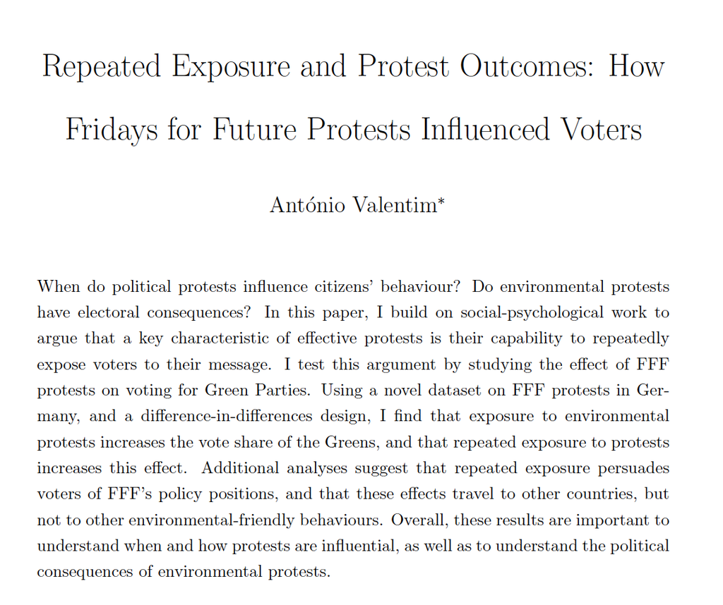

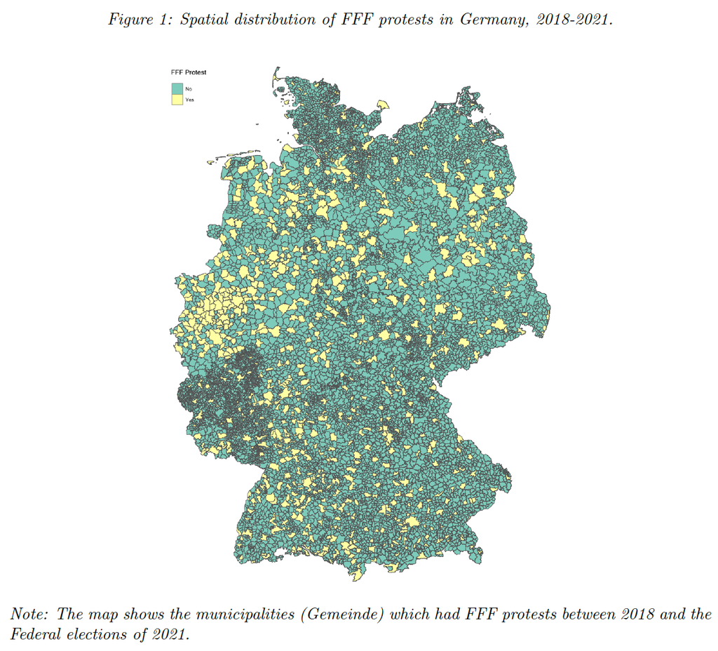

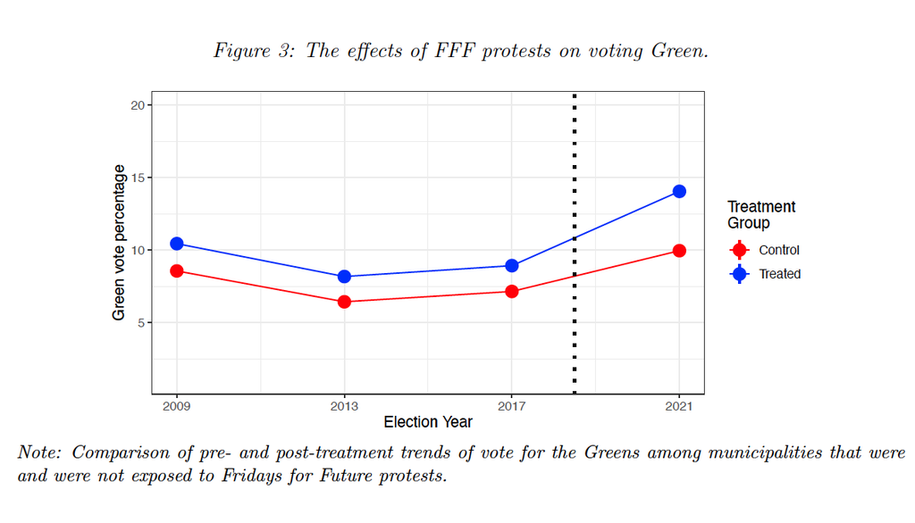

## Extra-ball: Combo (Jumps x Time)

[figure not shown]

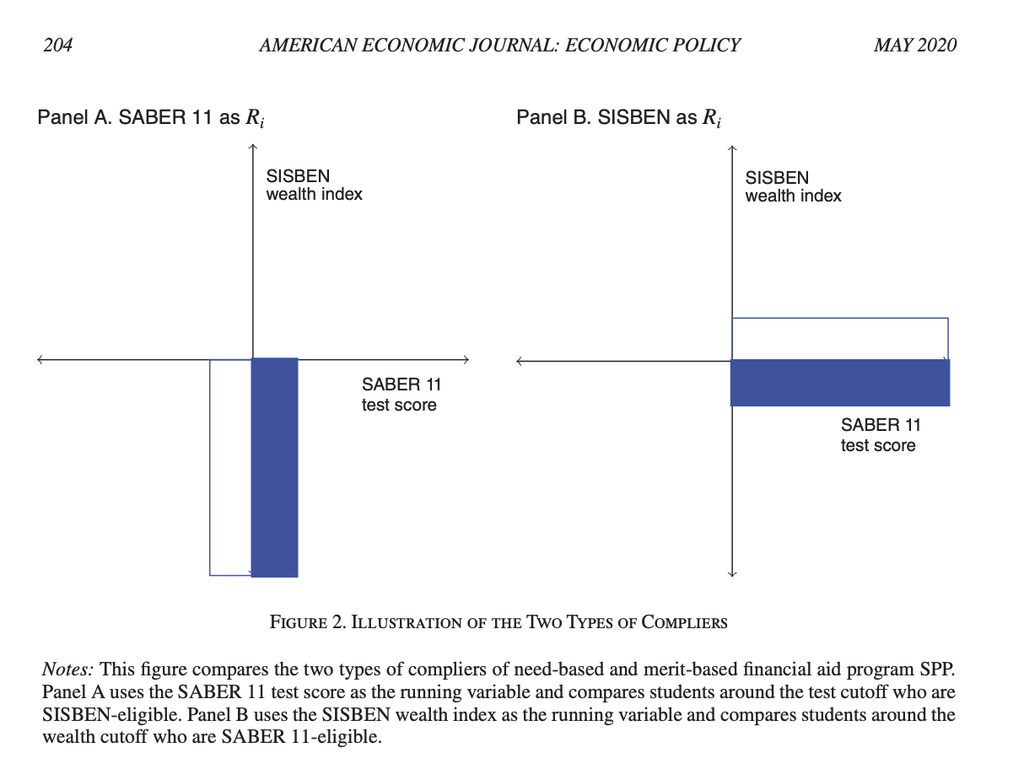

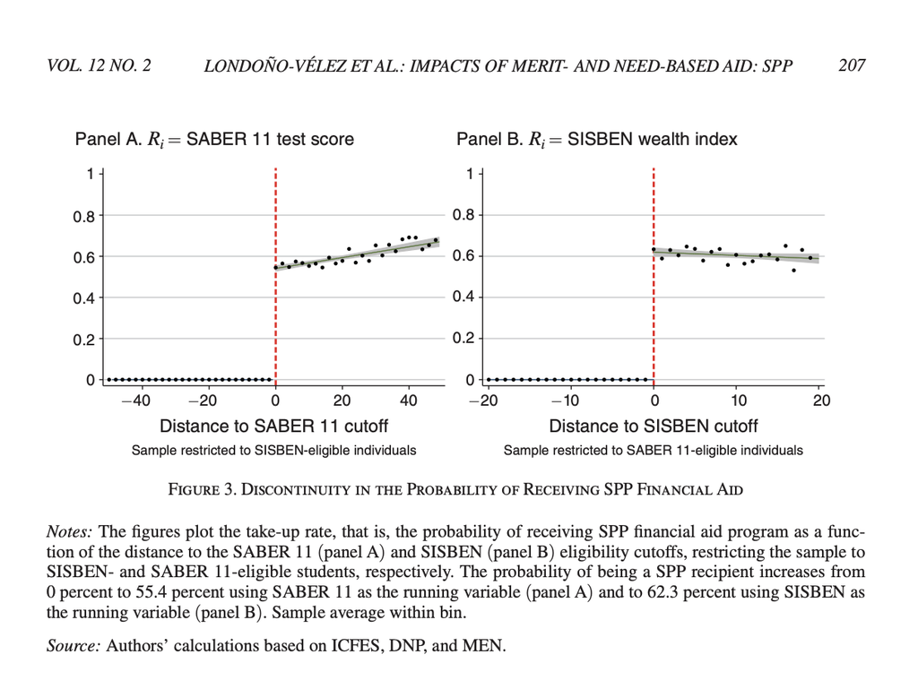

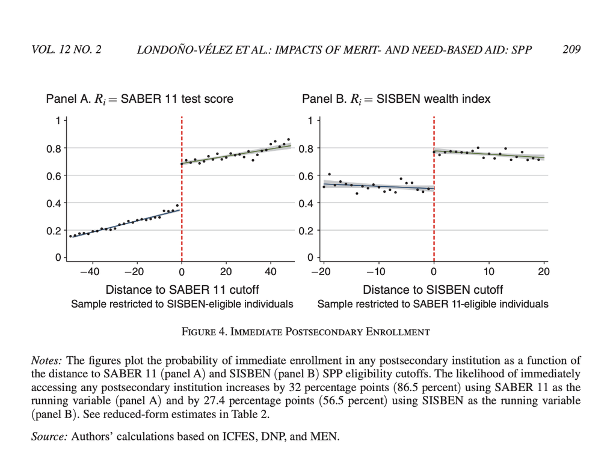

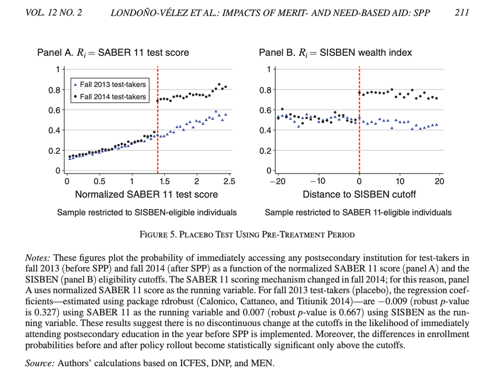

## Yet again

What’s missing here?

- Papers are still written using words
- **The story**, getting to **why, how, who, when** is the most important thing
- While writing your papers, spend time [*use your brains*] on the mechanism

[figure not shown]

## See you on Monday! Any doubts to smsoler@clio.uc3m.es

## Before that, remember:

1. Go to your drafts
2. Identify the paper that’s most similar to yours
3. Go to the paper, the version that has been published. Go to the journal website and look for the replication files. If absent, go to the youngest author’s website
4. If there’s no trace of replication data, go to the second paper that is most similar to yours…
5. Once you’ve identified it, tell me the title of the paper